# Finding fast growing firms

Maeva Braeckevelt and Brúnó Helmeczy

# Executive Summary

# Introduction

This analysis serves to predict fast growth of firms between 2012 and 2014. This analysis could help an investor to decide to invest in a certain company or not. The data was originally created by Bisnode, a major European business information company. The original dataset, bisnode-firms, considers companies between 2005 & 2016 in both Manufacturing (Electrical equipment, Motor vehicles, etc) & Services (Accommodation, and Food & Beverage services activities).

# Data

## Label Engineering

Firstly, we chose to define fast growth in terms of sales, more specifically, the compound annual growth rate of sales between 2012 & 2014 (Please see the formula specification below). We defined any firm with a % CAGR of at least 25% in the coming 2 years as a ‘Fast Growing’ firm, implying their sales would grow ca. 60% two years into the future. One reason for this, is the time-consuming administrative process of actually investing into firms.

$$CAGR = (\frac{Vfinal}{Vbegin})^\frac{1}{t} - 1$$

- **t** being the time in years, we defined it as 2.
- **Vbegin** is the Sales (in euro) in the year ongoing
- **Vfinal** is the Sales (in euro) the year +2

## Sample Design

As business context, we consider our client to be a silent investor group as of 2012, who is looking for suitable companies to invest in, with expected returns on their investments in 2 years. As such, we considered companies at least 1 year old, since such companies have already accumulated financial data over multiple years, yet many are young, with higher chances of gaining further market share. We only considered businesses generating annual sales between 100 thousand, & 10 million Euros, boasting sufficiently large sales for the business venture to be considered ‘serious’, yet small enough for it’s size not to be considered a disadvantage. After having design our sample, we end up with 14896 companies and 2413 of them (16%) are fast growing.

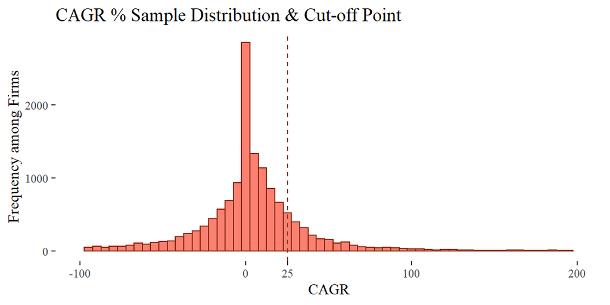

## Feature Engineering

Now, we need to select, clean & possibly transform our x variables. Some variables are financial accounts (e.g. inventories, current liabilities etc.) so they cannot be negative, thus we replaced the negative values to 0 & included flagging dummy variables to indicate our inputation. We created ratios, easier for interpretation & spotting extreme values. We also created new variables, e.g. change between the variable now & a year ago, we did it for the log of Sales (in million), inventories, total assets & amortization. Finally, we used a method called ‘winsorization’ on the change in sales & in total assets, to avoid extreme values. Afterwards, we grouped our variables, for easier interpretation, & better overview. Please see them below:

We chose to include some interactions as well, that we defined by common knwoledge.

- **Interaction** : Interactions with the sales growth, firm size, and industry

# Probability prediction and model selection

We decided to use three different models for the prediction of fast growing firm : Logit, Lasso and Random Forest. Our 5 Logistic regression models gradually incorporate more & more of the variable described groups above, where our final model, similarly to LASSO, incorporates all available variables. Finally, our Random Forest model considers all variable groups except interactions. We used a 5-fold cross-validation to estimate models and then we selected the best model based on expected loss. To calculate the expected loss we defined the cost of false negative and false positive errors.

## Define loss function

We first calculated the average CAGR amongst Hyper growth, & non-hyper growth companies. We found that companies labeled as hyper growth, on average have a CAGR of 64%, meaning they triple their size in terms of sales in 2 years. We assumed this implies our investors triple their money as well, giving us the base, true-positive scenario. Our False Negative case is when we do not decide to invest, but should have, implying the investors missed out on tripling the capital they would have invested, i.e. we set our False negative = -2.

## Modeling

The predictors of the first two models were handpicked and then we gradually add more categories at each models.

- **X1** : Log of sales in Millions, the square of the Log of sales in Millions , Winsorized value of the change of the log of Sales versus last year, profit and loss by total sales, Industries categories
- **X2** : X1, fixed assets divided by total assets, share equity divided by total assets,current liability divided by total assets, hight flags for current liability divided by total assets, flag error for current liability divided by total assets,age, foreign_management
- **X3** : Log of sales in Millions, the square of the Log of sales in Millions, Firm, Financial 1, Growth
- **X4** : Log of sales in Millions, the square of the Log of sales in Millions, Firm, Financial 1, Growth, *Financial 2*, *HR*, *Data quality*
- **X5** : Log of sales in Millions, the square of the Log of sales in Millions, Firm, Financial 1, Growth , Financial 2, HR, Data quality, *Interactions*
- **Lasso** : Log of sales in Millions, the square of the Log of sales in Millions, Firm, Financial 1, Growth , Financial 2, HR, Data quality, Interactions
- **Random Forest** : Log of sales in Millions, the square of the Log of sales in Millions, Firm, Financial 1, Growth , Financial 2, HR, Data quality

| Model | Number.of.predictors | CV.RMSE | CV.AUC | CV.threshold | CV.expected.Loss |
| --- | --- | --- | --- | --- | --- |
| X1 | 11 | 0.366 | 0.58 | 0.306 | 0.805 |
| X2 | 18 | 0.364 | 0.608 | 0.354 | 0.802 |
| X3 | 61 | 0.361 | 0.646 | 0.469 | 0.795 |
| X4 | 114 | 0.362 | 0.648 | 0.47 | 0.793 |
| X5 | 245 | 0.366 | 0.644 | 0.549 | 0.798 |
| LASSO | 26 | 0.361 | 0.625 | 0.488 | 0.8 |
| RandForest | 114 | 0.361 | 0.651 | 0.45 | 0.795 |

Please see all models summary statistics above. Observed the lowest Root Mean Square Error is 36.1 %, given by models X3, Lasso & Random forest. However all models were very close, the highest RMSE being 36.6%. The highest ‘Area Under the Curve’ is given by the Random Forest model, with AUC = 65,1%. I.e. Using this model, we are 15% better off than by simple random guessing, & 7% better off vs the base model, X1. However, like for the RMSE, the model X4 is very close to the Random forest with a AUC of 64,8%.

We base our final model selection on minimized expected loss, for which we first selected optimal classification threshold values of each model, thereby comparing the best possible expected loss for each model. The smaller expected loss is 0.793 is the model X4. Considering that it is a very theoretical concept, we only interpret it in relative terms: it is the lowest of all models, though our models again show little variation. Thus, our final model choice is Model X4. It had the lowest expected loss (the most important criteria), while the AUC & RMSE were very close to being the best.

## Ex-Sample Testing & Model Diagnostics

| Final_Model | Nr.Vars | RMSE | AUC | Threshold | Expected_Loss |
| --- | --- | --- | --- | --- | --- |
| Logit X4 | 114 | 0.362 | 0.648 | 0.47 | 0.803 |

Our model performs on the holdout set very similarly as during cross validation. The loss function slightly increased to 0,803, vs 0,793. The lack of variation between the holdout set & cross validation confirmed that we did not overfit our data, meanwhile still outperforming the benchmark model.

| prediction | no_Hyp.GrowthFinal_Model | Hyp.GrowthFinal_Model |
| --- | --- | --- |
| no_Hyp.Growth | 2471 | 466 |
| Hyp.Growth | 21 | 21 |

| HyperGrowth_f | AvgAnnGrowth | Firms_Selected | Investment_per_Firm | NetEarnings |
| --- | --- | --- | --- | --- |
| no_Hyp.Growth | -29.3 | 21 | 10000 | -105032 |
| Hyp.Growth | 85.9 | 21 | 10000 | 515735 |
| Total | 28.3 | 42 | 10000 | 410703 |

Let’s assume that we are advising an investor to invest in companies based on our model’s recommendation. The models predicted 42 companies with fast growing sales. If the investor invest 10000 euro in the 42 companies, he will lose 105.032 with the 21 companies that did not actually have fast growing sales. However, he will gain 515.735 euro with the 21 companies that actually did have fast growth sales. So, the win would be of 410 703 euro for 420 000 euro invested, a Return on Investment of 97.7%. Though our benchmark model netted higher ROI, it found only 17 firms to invest in, with 12 of them subject to false positive error. Thus, vs the benchmark, our final model found 25 more investment opportunities, & offers a better likelihood of the investment to be fruitful.

# Conclusion / Summary

This analysis aimed at predicting if a firm is growing fast in the coming two years, we used a large & complex dataset of firms from various industries. We specified 7 models: 5 logit, 1-1 Lasso & Random Forest. We defined our loss function to classify firms that would likely grow fast or not. After analysing the RMSE, the AUC, & loss function, we found the 4th Logit Model to be the best model, utilizing 114 variables. After evaluating our model in our holdout threshold, it predicted 42 firms would have a fast growth. Though half on them were false positive, we still significantly improved vs our benchmark models’ 29% true positive rate. Nevertheless, we calculated that if the investor invest in all recommended firms, the benefits gained by investing in fast growing firm will vastly compensate the losses incurred from less successful firms.